# Examen_VersionA

- Mostrar todo el código
- Ocultar todo el código
- Ver el código fuente

Autor/a

Brisa Danae Gutiérrez Bernal

Fecha de publicación

26 de noviembre de 2026

# Examen final de Introducción a R

**Código**

```r
library(readr)
library(dplyr)
library(tidyr)
library(ggplot2)
library(forcats)
library(scales)

dir.create("figuras", showWarnings = FALSE)
```

## 13.2 Importación y exportación

**Código**

```r
conteos  <- read_tsv("data_raw/datos_A/conteos_genero_miel_bacterias.tsv")
metadata <- read_csv("data_raw/datos_A/metadata_miel_examen.csv")

head(conteos)
```

```
# A tibble: 6 × 3
  sample_id genero        conteo
  <chr>     <chr>          <dbl>
1 Melli_21  Abiotrophia      806
2 Melli_21  Abyssalbus        66
3 Melli_21  Abyssibius         3
4 Melli_21  Abyssicoccus     853
5 Melli_21  Acaryochloris    867
6 Melli_21  Aceticella        11
```

**Código**

```r
glimpse(metadata)
```

```
Rows: 17
Columns: 14
$ sample_id            <chr> "Melli_21", "Melli_22", "Melli_39", "Melli_40", "…
$ species              <chr> "Melipona beecheii", "Melipona beecheii", "Melipo…
$ State                <chr> "QR", "QR", "QR", "QR", "QR", "QR", "Yuc", "Yuc",…
$ City                 <chr> "Jose Maria Morelos", "Jose Maria Morelos", "Jose…
$ Region               <chr> "Sureste", "Sureste", "Sureste", "Sureste", "Sure…
$ Zootechnic_mangement <chr> "Mixed honey", "Jobon", "Beehive box", "Beehive b…
$ Flowering_type       <chr> "Multifloral", "Multifloral", "Multifloral", "Mul…
$ Moisture             <dbl> 21.9, 21.5, 23.0, 25.0, 23.0, 21.9, 24.5, 22.0, 2…
$ HMF                  <dbl> 1.6, 3.4, 1.7, 4.0, 3.5, 1.0, 1.0, 1.0, 1.0, 1.0,…
$ Color                <chr> "Light Amber", "Extra Light Amber", "Extra Light …
$ pH                   <dbl> 6.175, 3.990, 4.580, 3.980, 4.780, 4.230, 3.990, …
$ Conductivity         <dbl> 366.0, 270.5, 146.9, 246.0, 201.0, 507.0, 372.5, …
$ Ash                  <dbl> 0.130, 0.075, 0.004, 0.061, 0.035, 0.211, 0.134, …
$ Total_sugar          <dbl> 468, 650, 642, 543, 449, 454, 624, 470, NA, 417, …
```

- Indica las dimensiones de ambas tablas y el número de muestras por especie de abeja.

### Dimensiones

**Código**

```r
dim(conteos)
```

```
[1] 37128     3
```

**Código**

```r
dim(metadata)
```

```
[1] 17 14
```

**Código**

```r
n_distinct(conteos$genero)
```

```
[1] 2184
```

**Código**

```r
conteos |> count(sample_id)
```

```
# A tibble: 17 × 2
   sample_id     n
   <chr>     <int>
 1 Melli_21   2184
 2 Melli_22   2184
 3 Melli_39   2184
 4 Melli_40   2184
 5 Melli_41   2184
 6 Melli_42   2184
 7 Melli_45   2184
 8 Melli_46   2184
 9 Melli_47   2184
10 Scapto_23  2184
11 Scapto_43  2184
12 Scapto_51  2184
13 Scapto_89  2184
14 Scapto_90  2184
15 Scapto_91  2184
16 Scapto_92  2184
17 Scapto_93  2184
```

### Número de muestras por especie

**Código**

```r
metadata |> count(species, name = "n_muestras")
```

```
# A tibble: 2 × 2
  species                n_muestras
  <chr>                       <int>
1 Melipona beecheii               9
2 Scaptotrigona mexicana          8
```

Hay 9 muestras de Melipona beecheii y 8 de Scaptotrigona mexicana.

- Identifica si existen valores faltantes en los metadatos e indica en qué variable o variables.

### Valores Faltantes

**Código**

```r
colSums(is.na(metadata))
```

```
           sample_id              species                State
                   0                    0                    0
                City               Region Zootechnic_mangement
                   0                    0                    0
      Flowering_type             Moisture                  HMF
                   0                    0                    0
               Color                   pH         Conductivity
                   0                    0                    0
                 Ash          Total_sugar
                   0                    2
```

**Código**

```r
names(metadata)[colSums(is.na(metadata)) > 0]
```

```
[1] "Total_sugar"
```

**Código**

```r
metadata |> filter(is.na(Total_sugar)) |> select(sample_id, species, Total_sugar)
```

```
# A tibble: 2 × 3
  sample_id species                Total_sugar
  <chr>     <chr>                        <dbl>
1 Melli_47  Melipona beecheii               NA
2 Scapto_90 Scaptotrigona mexicana          NA
```

Existen 2 variables faltantes en los metadatos en la variable “Total_sugar”

## 13.3 Integración y abundancia relativa

Integra las dos tablas mediante el identificador sample_id. Calcula la abundancia relativa de cada género dentro de cada muestra, dividiendo su conteo entre la suma de los conteos de esa muestra. Conserva las abundancias como proporciones entre 0 y 1.

**Código**

```r
abund <- conteos |>
  left_join(metadata, by = "sample_id") |>
  group_by(sample_id) |>
  mutate(abundancia_rel = conteo / sum(conteo)) |>
  ungroup()

abund |> select(sample_id, species, genero, conteo, abundancia_rel) |> head()
```

```
# A tibble: 6 × 5
  sample_id species           genero        conteo abundancia_rel
  <chr>     <chr>             <chr>          <dbl>          <dbl>
1 Melli_21  Melipona beecheii Abiotrophia      806    0.000132
2 Melli_21  Melipona beecheii Abyssalbus        66    0.0000108
3 Melli_21  Melipona beecheii Abyssibius         3    0.000000491
4 Melli_21  Melipona beecheii Abyssicoccus     853    0.000140
5 Melli_21  Melipona beecheii Acaryochloris    867    0.000142
6 Melli_21  Melipona beecheii Aceticella        11    0.00000180
```

**Código**

```r
abund |>
  group_by(sample_id) |>
  summarise(suma = sum(abundancia_rel))
```

```
# A tibble: 17 × 2
   sample_id  suma
   <chr>     <dbl>
 1 Melli_21  1.000
 2 Melli_22  1.000
 3 Melli_39  1.000
 4 Melli_40  1.000
 5 Melli_41  1.00
 6 Melli_42  1.000
 7 Melli_45  1.000
 8 Melli_46  1
 9 Melli_47  1.00
10 Scapto_23 1.000
11 Scapto_43 1
12 Scapto_51 1.000
13 Scapto_89 1.00
14 Scapto_90 1.00
15 Scapto_91 1
16 Scapto_92 1.00
17 Scapto_93 1.00
```

**Código**

```r
sum(is.na(abund$species))
```

```
[1] 0
```

## 13.4 Figura 1: los 10 géneros más abundantes

Calcula la abundancia relativa promedio de cada género considerando las 17 muestras, incluidos los conteos cero. Selecciona los diez con mayor promedio y reproduce la gráfica de barras horizontales ordenadas de mayor a menor. Muestra el eje de abundancia en porcentajes y agrega etiquetas apropiadas.

**Código**

```r
top10 <- abund |>
  group_by(genero) |>
  summarise(promedio = mean(abundancia_rel)) |>
  arrange(desc(promedio)) |>
  slice_head(n = 10)

top10
```

```
# A tibble: 10 × 2
   genero              promedio
   <chr>                  <dbl>
 1 Acetilactobacillus    0.314
 2 Apilactobacillus      0.0653
 3 Nicoliella            0.0617
 4 Lactobacillus         0.0356
 5 Lentilactobacillus    0.0266
 6 Fructilactobacillus   0.0258
 7 Ligilactobacillus     0.0206
 8 Pediococcus           0.0198
 9 Tatumella             0.0195
10 Limosilactobacillus   0.0187
```

**Código**

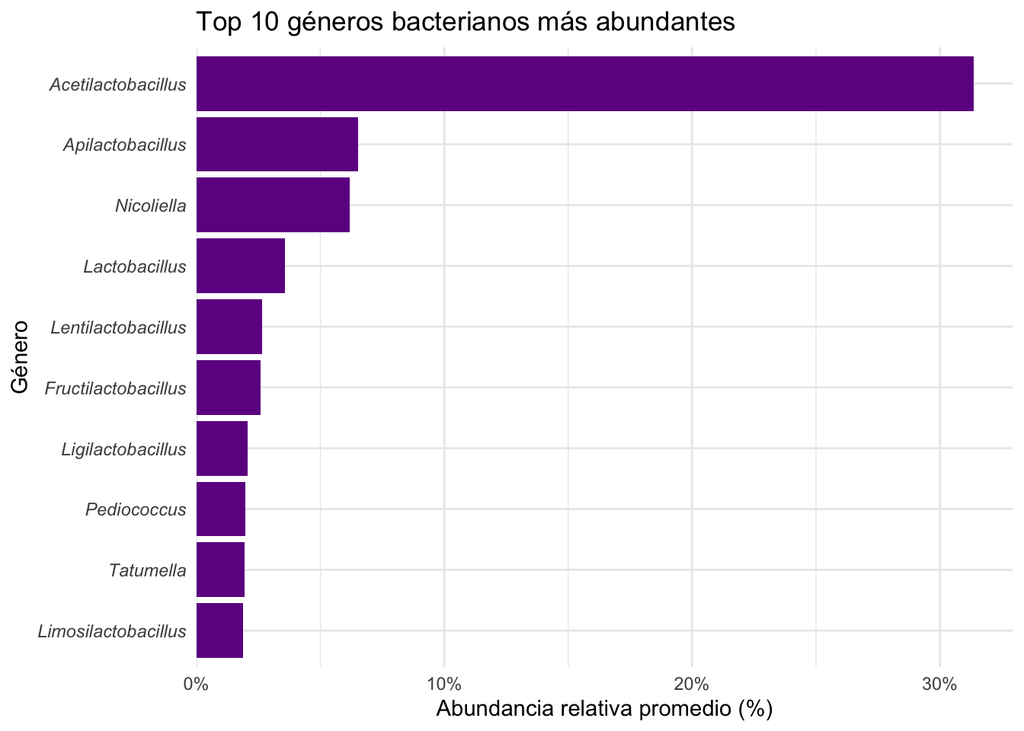

Figura 1: Figura 1. Los 10 géneros más abundantes.

```r
fig1 <- ggplot(top10, aes(x = promedio, y = fct_reorder(genero, promedio))) +
  geom_col(fill = "#701B91") +
  scale_x_continuous(labels = percent_format(accuracy = 1),
                     expand = expansion(mult = c(0, 0.05))) +
  labs(title = "Top 10 géneros bacterianos más abundantes",
       x = "Abundancia relativa promedio (%)",
       y = "Género") +
  theme_minimal() +
  theme(axis.text.y = element_text(face = "italic"))

fig1
ggsave("figuras/figura1_top10_generos.png", fig1, width = 7, height = 5, dpi = 300)
```

## 13.5 Figura 2: composición bacteriana por muestra

Utiliza las abundancias relativas del apartado 2, no solamente los diez taxones de la figura anterior.

Dentro de cada muestra, agrupa los géneros cuya abundancia relativa sea estrictamente menor al 5 % en la categoría Géneros < 5%. Suma las abundancias de esa categoría. Construye una gráfica de barras apiladas, una barra por muestra, separando las especies de abejas mediante facetas. Cada barra debe sumar 100 %. Utiliza la paleta proporcionada y coloca la leyenda debajo de la gráfica.

**Código**

```r
genus_colors <- c(
  "Acetilactobacillus" = "#5B3794",
  "Apilactobacillus" = "#9953A1",
  "Lactobacillus" = "#BA4B8E",
  "Nicoliella" = "#C87AAD",
  "Pantoea" = "#EBA8BA",
  "Tatumella" = "#F8DCD9",
  "Fructobacillus" = "#B494D5",
  "Géneros < 5%" = "#C6B2CB"
)
```

**Código**

```r
composicion <- abund |>
  mutate(genero_plot = if_else(abundancia_rel < 0.05,
                               "Géneros < 5%", genero)) |>
  group_by(sample_id, species, genero_plot) |>
  summarise(abundancia_rel = sum(abundancia_rel), .groups = "drop") |>
  mutate(genero_plot = factor(genero_plot, levels = names(genus_colors)))

composicion |>
  group_by(sample_id) |>
  summarise(suma = sum(abundancia_rel))
```

```
# A tibble: 17 × 2
   sample_id  suma
   <chr>     <dbl>
 1 Melli_21  1.00
 2 Melli_22  1.000
 3 Melli_39  1
 4 Melli_40  1
 5 Melli_41  1.00
 6 Melli_42  1.00
 7 Melli_45  1
 8 Melli_46  1
 9 Melli_47  1
10 Scapto_23 1.000
11 Scapto_43 1.00
12 Scapto_51 1
13 Scapto_89 1.00
14 Scapto_90 1.00
15 Scapto_91 1.00
16 Scapto_92 1.00
17 Scapto_93 1.00
```

**Código**

```r
levels(droplevels(composicion$genero_plot))
```

```
[1] "Acetilactobacillus" "Apilactobacillus"   "Lactobacillus"
[4] "Nicoliella"         "Pantoea"            "Tatumella"
[7] "Fructobacillus"     "Géneros < 5%"
```

**Código**

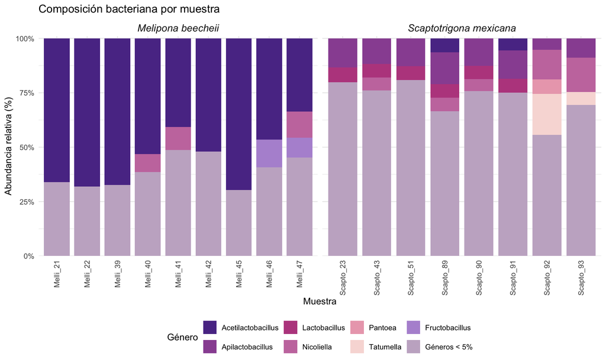

Figura 2: Figura 2. Composición bacteriana por muestra.

```r
fig2 <- ggplot(composicion,
               aes(x = sample_id, y = abundancia_rel, fill = genero_plot)) +
  geom_col(width = 0.85) +
  facet_wrap(~ species, scales = "free_x") +
  scale_fill_manual(values = genus_colors) +
  scale_y_continuous(labels = percent_format(),
                     expand = expansion(mult = c(0, 0.01))) +
  labs(title = "Composición bacteriana por muestra",
       x = "Muestra", y = "Abundancia relativa (%)", fill = "Género") +
  theme_minimal() +
  theme(legend.position = "bottom",
        axis.text.x = element_text(angle = 90, vjust = 0.5, hjust = 1),
        strip.text = element_text(face = "italic", size = 12)) +
  guides(fill = guide_legend(nrow = 2))

fig2
ggsave("figuras/figura2_composicion_muestras.png", fig2, width = 10, height = 6, dpi = 300)
```

## 13.6 Interpretación

1. ¿Cuál es el género con mayor abundancia relativa promedio?

Acetilactobacillus con una abundancia relativa promedio de ~32%.

2. ¿Qué diferencias o similitudes observas en la composición de las muestras de las dos especies de abejas? Describe lo observado sin atribuir causalidad.